# Weather Discriminator Analysis

Order Multipliers

PR

February 03, 2026

```r
library(tidyverse)
library(here)
model_data <- here("data","model","model_data_2.2.rds") %>% read_rds()
```

# 1 Recommended Fit

```r
# Recommended Fit
ord_fit <- MASS::polr(
  outcome_label ~ weather_category,
  data = model_data,
  Hess = TRUE
)
summary(ord_fit)
```

```
## Call:
## MASS::polr(formula = outcome_label ~ weather_category, data = model_data,
##     Hess = TRUE)
##
## Coefficients:
##                                 Value Std. Error t value
## weather_categoryneutral_weather 1.211     0.4570   2.650
## weather_categorygood_weather    1.417     0.2644   5.358
##
## Intercepts:
##                  Value   Std. Error t value
## bad_day|neutral  -0.3852  0.1889    -2.0385
## neutral|good_day  2.0248  0.2354     8.6010
##
## Residual Deviance: 514.5686
## AIC: 522.5686
```

# 2 Inspection

## 2.1 Outcome Labels

```r
model_data %>% count(weather_category, outcome_label) %>%
  pivot_wider(
    names_from = outcome_label, values_from = n
  )
```

| weather_category | bad_day | neutral | good_day |
| --- | --- | --- | --- |
| bad_weather | 46 | 49 | 15 |
| neutral_weather | 4 | 11 | 7 |
| good_weather | 16 | 70 | 44 |

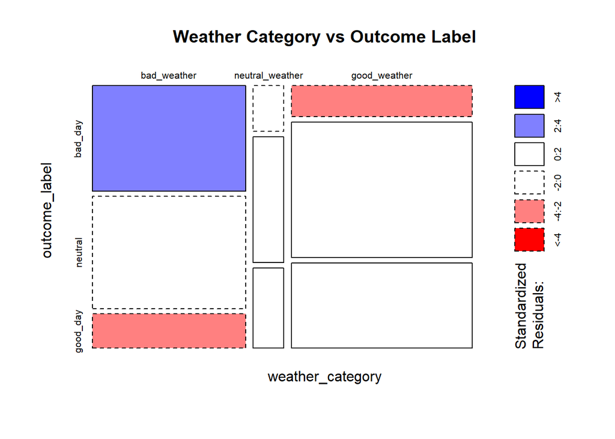

```r
with(model_data,
     mosaicplot(table(weather_category, outcome_label),
                main = "Weather Category vs Outcome Label",
                col = c(bad = "red", neutral = "grey70", good = "steelblue"),
                shade = TRUE))
```

Recommendations:

- Effect of **bad_weather** (to predict bad_day = lower sales), on sales is **more reliable**.
  - Why? large number of bad days with bad weather, more than you would expect due to chance.
- Effect of **good_weather** (to predict good_day = higher sales) on sales is **less reliable.**
  - Why? large number of good_weather days with with neutral outcome (average sales)

## 2.2 Weather and day categories

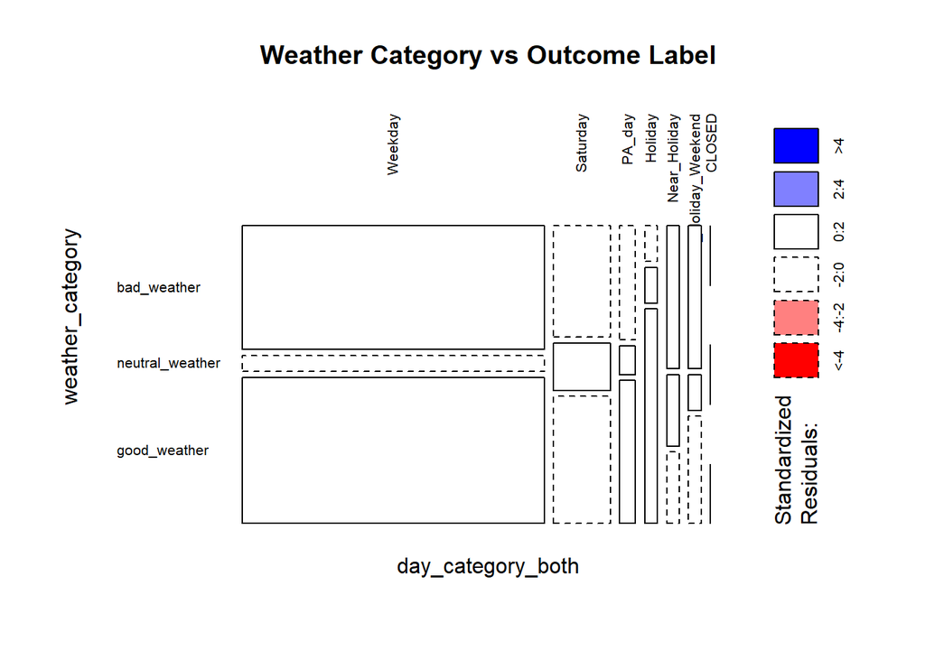

```r
with(model_data,
     mosaicplot(table(day_category_both, weather_category),
                main = "Weather Category vs Outcome Label",
                col = c(bad = "red", neutral = "grey70", good = "steelblue"),
                shade = TRUE,
                las = 2))
```

## 2.3 Distribution of num_items by weather_category

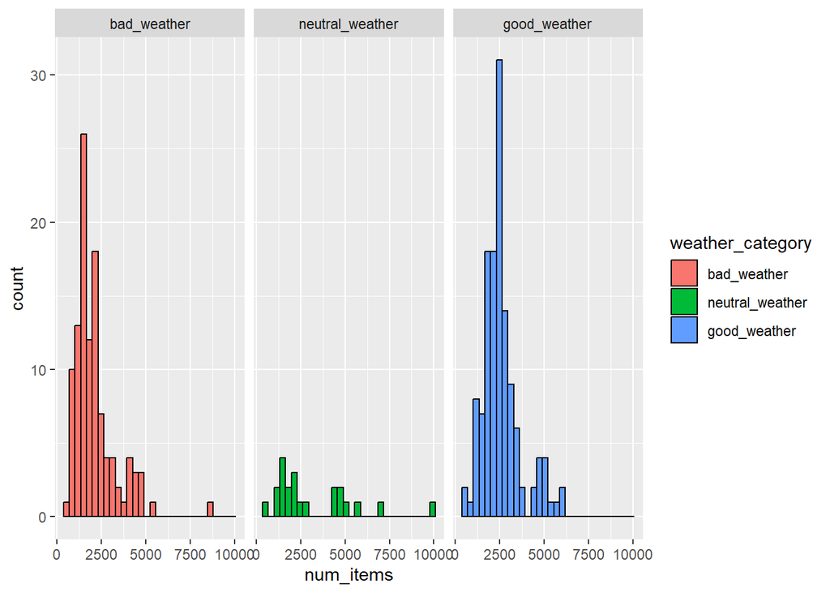

```r
model_data %>% ggplot(aes(x = num_items, fill = weather_category)) +
  geom_histogram(color = "black", bins = 30) +
  facet_wrap(~weather_category)
```

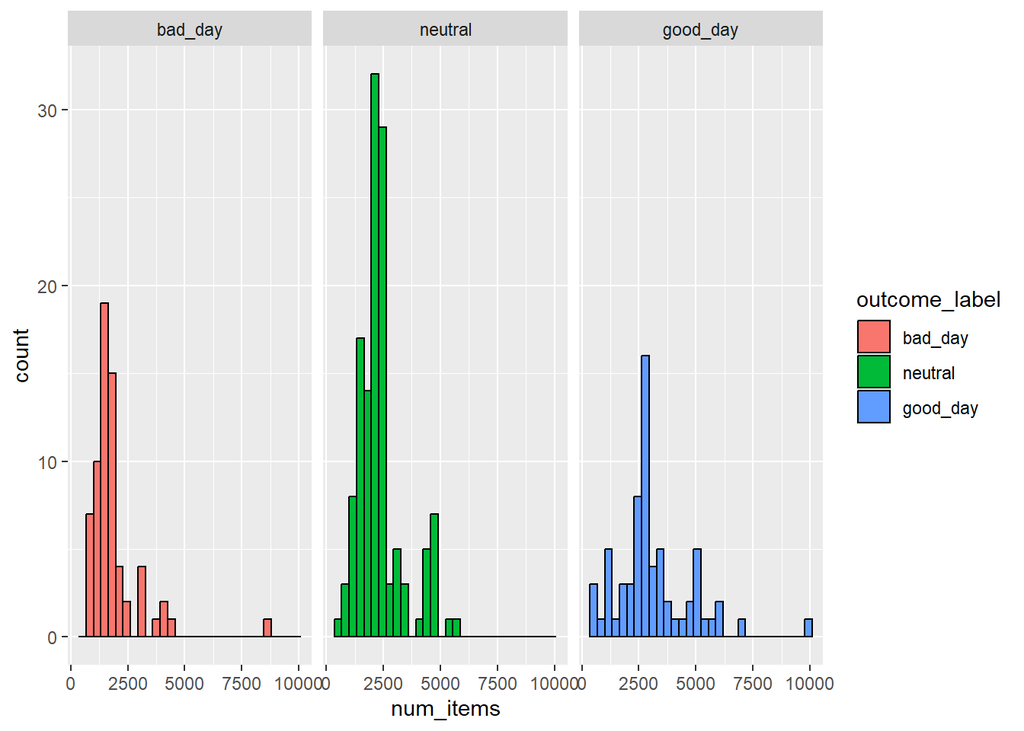

```r
model_data %>% ggplot(aes(x = num_items, fill = outcome_label)) +
  geom_histogram(color = "black", bins = 30) +
  facet_wrap(~outcome_label)
```

So many good_weather days end up being neutral sales days.

# 3 Multipliers

**Goal:** empirically determine multipliers for good, neutral, and bad weather days.

## 3.1 Mean-based multipliers

```r
exp_items <- mean(model_data$num_items)
exp_items
```

```
## [1] 2432.111
```

```r
exp_hat <- mean(model_data$num_items_pred)
exp_hat
```

```
## [1] 2432.111
```

```r
order_multipliers <- model_data %>% group_by(weather_category) %>%
  summarize(
    m_residuals = mean(num_items_residual),
    m_num_items = mean(num_items),
    m_num_items_hat = mean(num_items_pred),
    .groups = "drop"
  ) %>% mutate(
    multiplier_data = m_num_items/exp_items,
    multiplier_hat  = m_num_items_hat/exp_hat
  ) %>% relocate(
    multiplier_data, .after = m_num_items
  )
order_multipliers
```

| weather_category | m_residuals | m_num_items | multiplier_data | m_num_items_hat | multiplier_hat |
| --- | --- | --- | --- | --- | --- |
| bad_weather | -223.6221 | 2106.018 | 0.865922 | 2329.640 | 0.9578677 |
| neutral_weather | 129.6175 | 3188.682 | 1.311076 | 3059.064 | 1.2577817 |
| good_weather | 167.2835 | 2580.000 | 1.060807 | 2412.717 | 0.9920258 |

No go because of data skew

## 3.2 Median-based multipliers

Not recommended

```r
exp_items <- median(model_data$num_items)
exp_items
```

```
## [1] 2182.5
```

```r
exp_hat <- median(model_data$num_items_pred)
exp_hat
```

```
## [1] 2264.355
```

```r
order_multipliers <- model_data %>% group_by(weather_category) %>%
  summarize(
    m_residuals = median(num_items_residual),
    m_num_items = median(num_items),
    m_num_items_hat = median(num_items_pred),
    .groups = "drop"
  ) %>% mutate(
    multiplier_data = m_num_items/exp_items,
    multiplier_hat  = m_num_items_hat/exp_hat
  ) %>% relocate(
    multiplier_data, .after = m_num_items
  )
order_multipliers
```

| weather_category | m_residuals | m_num_items | multiplier_data | m_num_items_hat | multiplier_hat |
| --- | --- | --- | --- | --- | --- |
| bad_weather | -211.5070 | 1747.0 | 0.8004582 | 2133.911 | 0.9423924 |
| neutral_weather | 132.8022 | 2204.0 | 1.0098511 | 2203.695 | 0.9732109 |
| good_weather | 129.7072 | 2360.5 | 1.0815578 | 2294.329 | 1.0132372 |

## 3.3 Ratio of Sums (exposure-weighted mean)

```r
multipliers <- model_data %>% group_by(weather_category) %>%
  summarize(
    multiplier = (sum(num_items) / sum(num_items_pred)) %>% round(3)
  )
multipliers
```

| weather_category | multiplier |
| --- | --- |
| bad_weather | 0.904 |
| neutral_weather | 1.042 |
| good_weather | 1.069 |

Why this is appropriate:

- Immune to single-day spikes dominating category means (e.g. Thanksgiving)
- Preserves total volume (critical for ordering)
- Aligns perfectly with your baseline model
- Standard practice in demand planning & actuarial work

# 4 Final Mutliplier Recommendations

Based on ration of sums multipliers:

- For good weather days: use +7% order adjustment, to be used conservatively
- For neutral weather days: use +4% order adjustment, to be used for extreme temps (projected high outside 12-32 degrees C) or extreme winds
- For bad weather days: use -10% order adjustment, to be used when high chance of rain

Note on *neutral weather* terminology. Is not really neutral. Just not great. Open to suggestions.

```r
multipliers <- model_data %>% group_by(weather_category) %>%
  summarize(
    multiplier = (sum(num_items) / sum(num_items_pred)) %>% round(2)
  )
multipliers
```

| weather_category | multiplier |
| --- | --- |
| bad_weather | 0.90 |
| neutral_weather | 1.04 |
| good_weather | 1.07 |